# Applying an ICAR reference prior

# 1 Introduction

# 2 Functions

**ref.ICAR** can be used to analyze areal data corresponding to a contiguous region, provided a shapefile or neighborhood matrix and data. The functions implemented by **ref.ICAR** are summarized below.

- `shape.H()` Takes a file path to a shapefile and forms the appropriate neighborhood matrix for analysis with the ICAR reference prior model.
- `ref.MCMC()` Implements the posterior sampling algorithm proposed by Keefe et al. (2019). Generates MCMC chains for parameter and regional inferences.
- `ref.summary()` Provides posterior inferences for the model parameters, $\tau$, $\boldsymbol{\beta}$, and $\sigma^2$. Includes posterior medians, highest posterior density (HPD) intervals, and acceptance rates for each parameter.
- `reg.summary()` Provides fitted posterior values and summaries for each subregion in the areal data set. Includes posterior medians and HPD intervals by region.
- `ref.plot()` Outputs trace plots for the model parameters, $\tau$, $\boldsymbol{\beta}$, and $\sigma^2$.
- `ref.analysis()` Performs analysis by sequentially implementing each of the functions above. This function produces plots and a list containing MCMC chains, parameter estimates, regional estimates, and sampling acceptance rates.
- `probs.icar()` Performs simultaneous, objective Bayesian model selection for covariates and spatial model structure for areal data. This function provides posterior model probabilities for all candidate ICAR models and OLMs.

# 3 ICAR Model Summary

The model implemented by **ref.ICAR** is summarized below.
$$\begin{equation}
\mathbf{Y}= X
\boldsymbol{\boldsymbol{\beta}}+\boldsymbol{\theta}+\boldsymbol{\phi}
\end{equation}$$

where

- $\mathbf{Y}$ is an $n\times1$ vector for the response variable, where $n$ corresponds to the number of regions in the shapefile. The current version of the package does not allow for missing data.
- $X$ is a matrix of covariates. This can include a vector $\textbf{1}_n$ for an intercept, and additional columns corresponding to quantitative predictors.
- $\boldsymbol{\boldsymbol{\beta}}$ is the $p\times1$ vector of fixed effect regression coefficients, where $p$ corresponds to the number of columns in $X$.
- $\boldsymbol{\theta}$ is an $n\times1$ vector of independent and normally distributed unstructured random effects defined with mean 0 and variance $\sigma^2$.
- $\boldsymbol{\phi}$ is an $n\times1$ vector of spatial random effects that is assigned an intrinsic CAR prior with the sum-zero constraint $\sum_{i=1}^n \phi_i=0$ (Keefe et al. 2018).

The model assumes a signal-to-noise ratio parameterization for the variance components of the random components of the model, so $\sigma^2$ and $\tau$ are used as below.
$$\boldsymbol{\phi} \sim
\bigg(\textbf{0},\frac{\sigma^2}{\tau}\Sigma_{\phi}\bigg)$$

The parameter $\tau$ controls the strength of spatial dependence, and given the neighborhood structure, $\Sigma_{\phi}$ is a fixed matrix. Specifically, $\Sigma_{\phi}$ is the Moore-Penrose inverse of $H$, where the neighborhood matrix $H$ is an $n\times n$ symmetric matrix constructed as follows.
$$\begin{equation}
(H)_{ij} =
\begin{cases}
h_i & \text{if } i=j \\
-g_{ij} & \text{if } i\in N_j \\
0 & \text{otherwise},
\end{cases}
\end{equation}$$

where $g_{ij}=1$ if subregions $i$ and $j$ are neighbors, $g_{ij}=0$ if subregions i and j are not neighbors,and $h_i$ is the number of neighbors of subregion $i$. Therefore, the neighborhood matrix $H$ is an $n\times n$ symmetric matrix where the diagonal elements correspond to the number of neighbors for each subregion in the data, and each off-diagonal element equals $-1$ if the corresponding subregions are neighbors.

Provided a path to a shapefile, the `shape.H()` function in **ref.ICAR** constructs $H$ as specified above, and checks for symmetry and contiguous regions (i.e. no islands) prior to analysis. The functions `shape.H()` and `ref.analysis()` requires a file path to a shapefile. If a user wants to analyze areal data without a corresponding shapefile (e.g. neuroimaging), they will need to construct $H$ as above and use this $H$ in `ref.MCMC()`. `ref.plot()`,`ref.summary()`, and `reg.summary()` can then be used with the MCMC chains obtained from `ref.MCMC()`. Additionally, if a user performs analysis without `ref.analysis()`, the regions corresponding to data values in $X$ and $y$ must match the region order in $H$; otherwise inferences will be matched to incorrect regions.

# 4 Example: Objective ICAR Inference

Consider an example of areal data over the contiguous United States. Figure 1 represents the average SAT scores reported in 1999 for each of the contiguous United States and Washington D.C. This example will explore these data and use the **ref.ICAR** package to fit a model to the response, Verbal SAT scores, considering spatial dependence and a single covariate, percent of eligible students that took the SAT in each state in 1999. This data was analyzed in *Hierarchical Modeling and Analysis for Spatial Data* (Banerjee et al. 2014). The data are available online at https://www.counterpointstat.com/hierarchical-modeling-and-analysis-for-spatial-data.html. We make it available in the **ref.ICAR** package with permission from the authors. The shapefile is found from http://www.arcgis.com/home/item.html?id=f7f805eb65eb4ab787a0a3e1116ca7e5.

These data and the accompanying shapefile are attached to the **ref.ICAR** package. The files can be loaded into R as shown below. The `st_read()` function from package **sf** is used to read the shapefile.

```r
system.path <- system.file("extdata", "us.shape48.shp", package = "ref.ICAR",
    mustWork = TRUE)
shp.layer <- gsub(".shp", "", basename(system.path))
shp.path <- dirname(system.path)

us.shape48 <- st_read(dsn = path.expand(shp.path), layer = shp.layer,
    quiet = TRUE)
```

The SAT data can be loaded into R from **ref.ICAR** using `read.table()`.

```r
data.path <- system.file("extdata", "states-sats48.txt", package = "ref.ICAR",
    mustWork = TRUE)

sats48 <- read.table(data.path, header = T)
us.shape48$verbal <- sats48$VERBAL
us.shape48$percent <- sats48$PERCENT
```

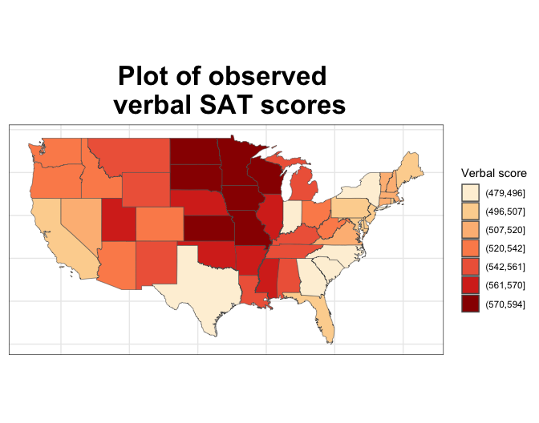

Figure 1: Observed Verbal SAT Scores

```r
breaks_qt <- classIntervals(c(min(us.shape48$verbal) - 1e-05,
    us.shape48$verbal), n = 7, style = "quantile")

us.shape48_sf <- mutate(us.shape48, score_cat = cut(verbal, breaks_qt$brks))
ggplot(us.shape48_sf) + geom_sf(aes(fill = score_cat)) + scale_fill_brewer(palette = "OrRd") +
    labs(title = "Plot of observed \n verbal SAT scores") + theme_bw() +
    theme(axis.ticks.x = element_blank(), axis.text.x = element_blank(),
        axis.ticks.y = element_blank(), axis.text.y = element_blank(),
        axis.title = element_text(size = 25, face = "bold"),
        plot.title = element_text(face = "bold", size = 25, hjust = 0.5)) +
    guides(fill = guide_legend("Verbal score"))
```

Similarly, the covariate, percent of eligible students taking the SAT, can be plotted over the contiguous United States. These data exhibit a seemingly inverse relationship to the SAT scores; lower percentages of students take the SAT in the Midwest.

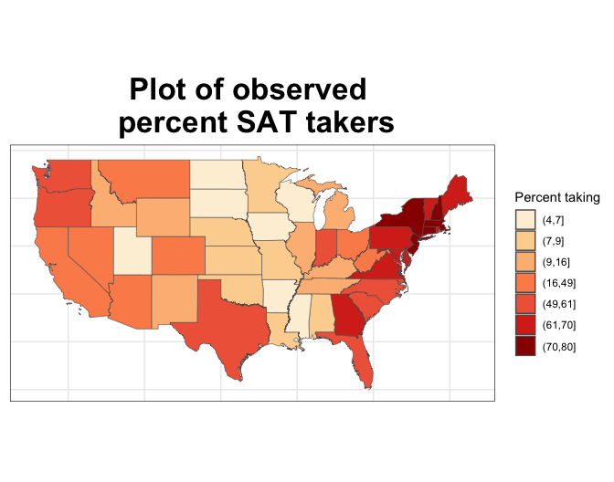

Figure 2: Percent of eligible students taking the SAT

```r
breaks_qt <- classIntervals(c(min(us.shape48$percent) - 1e-05,
    us.shape48$percent), n = 7, style = "quantile")

us.shape48_sf <- mutate(us.shape48, pct_cat = cut(percent, breaks_qt$brks))
ggplot(us.shape48_sf) + geom_sf(aes(fill = pct_cat)) + scale_fill_brewer(palette = "OrRd") +
    labs(title = "Plot of observed \n percent SAT takers") +
    theme_bw() + theme(axis.ticks.x = element_blank(), axis.text.x = element_blank(),
    axis.ticks.y = element_blank(), axis.text.y = element_blank(),
    axis.title = element_text(size = 25, face = "bold"), plot.title = element_text(face = "bold",
        size = 25, hjust = 0.5)) + guides(fill = guide_legend("Percent taking"))
```

```r
shp.data <- shape.H(system.path)
```

```r
H <- shp.data$H

class(shp.data$map)
```

```
## [1] "sf"         "data.frame"
```

```r
length(shp.data$map)
```

```
## [1] 7
```

The response and covariates, $Y$ and $X$ must be defined before fitting the model. The response, $Y$, is Verbal SAT scores. $X$ has two columns corresponding to an intercept and the predictor, percent of eligible students taking the SAT in 1999.

```r
Y <- sats48$VERBAL
x <- sats48$PERCENT
X <- cbind(1, x)
```

Then sampling can be performed using `ref.MCMC()`. The default starting values are used below, with MCMC iterations and burn-in larger than the default. The sampling for `ref.MCMC()` is based on developments by Ferreira et al. (2021), who express the spatial hierarchical model in the spectral domain to obtain the faster Spectral Gibbs Sampler (SGS). Previous versions of **ref.ICAR** implemented the Spectral Decomposition of the Precision (SDP) algorithm proposed by Keefe et al. (2019). See Ferreira et al. (2021) for an outline of the algorithm and computational comparisons.

```r
set.seed(3456)

ref.SAT <- ref.MCMC(y = Y, X = X, H = H, iters = 15000, burnin = 5000,
    verbose = FALSE)

names(ref.SAT)
```

```
## [1] "MCMCchain"     "tauc.MCMC"     "sigma2.MCMC"   "beta.MCMC"
## [5] "phi.MCMC"      "accept.phi"    "accept.sigma2" "accept.tauc"
```

The object ref.SAT contains MCMC chains for each of the parameters in the model $\mathbf{Y}= X \boldsymbol{\boldsymbol{\beta}}+\boldsymbol{\theta}+\boldsymbol{\phi}$, using a signal-to-noise ratio parameterization. From these, the function `ref.plot()` creates trace plots for each parameter to visually confirm convergence.

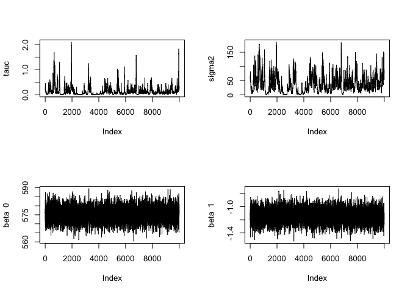

```r
par(mfrow = c(2, 2))
ref.plot(ref.SAT$MCMCchain, X, burnin = 5000, num.reg = length(Y))
```

```r
summary.params <- ref.summary(MCMCchain = ref.SAT$MCMCchain,
    tauc.MCMC = ref.SAT$tauc.MCMC, sigma2.MCMC = ref.SAT$sigma2.MCMC,
    beta.MCMC = ref.SAT$beta.MCMC, phi.MCMC = ref.SAT$phi.MCMC,
    accept.phi = ref.SAT$accept.phi, accept.sigma2 = ref.SAT$accept.sigma2,
    accept.tauc = ref.SAT$accept.tauc, iters = 15000, burnin = 5000)

names(summary.params)
```

```
## [1] "beta.median"   "beta.hpd"      "tauc.median"   "tauc.hpd"
## [5] "sigma2.median" "sigma2.hpd"    "tauc.accept"   "sigma2.accept"
```

```r
summary.params
```

```
## $beta.median
## [1] 575.461382  -1.142777
##
## $beta.hpd
##           lower       upper
## var1 568.028129 582.5163300
## var2  -1.334464  -0.9487258
##
## $tauc.median
## [1] 0.08581395
##
## $tauc.hpd
##        lower        upper
## 0.0003402439 0.5212723440
##
## $sigma2.median
## [1] 31.2014
##
## $sigma2.hpd
##      lower      upper
##  0.1604447 96.0084162
##
## $tauc.accept
## [1] 0.3436667
##
## $sigma2.accept
## [1] 0.3436667
```

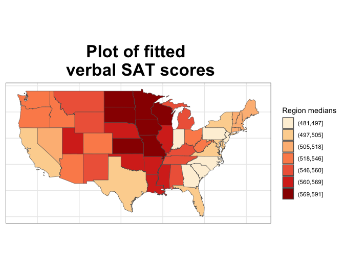

Figure 3: Posterior Medians for Verbal SAT

```r
summary.region <- reg.summary(ref.SAT$MCMCchain, X, Y, burnin = 5000)

us.shape48$verbalfits <- summary.region$reg.medians

breaks_qt <- classIntervals(c(min(us.shape48$verbalfits) - 1e-05,
    us.shape48$verbalfits), n = 7, style = "quantile")

us.shape48_sf <- mutate(us.shape48, reg_cat = cut(verbalfits,
    breaks_qt$brks))
ggplot(us.shape48_sf) + geom_sf(aes(fill = reg_cat)) + scale_fill_brewer(palette = "OrRd") +
    labs(title = "Plot of fitted \n verbal SAT scores") + theme_bw() +
    theme(axis.ticks.x = element_blank(), axis.text.x = element_blank(),
        axis.ticks.y = element_blank(), axis.text.y = element_blank(),
        axis.title = element_text(size = 25, face = "bold"),
        plot.title = element_text(face = "bold", size = 25, hjust = 0.5)) +
    guides(fill = guide_legend("Region medians"))
```

Finally, the function `ref.analysis()` in **ref.ICAR** performs the entire reference analysis, including:

- Obtaining the neighborhood matrix, $H$
- Running the MCMC chains
- Producing parameter trace plots
- Producing parameter summaries
- Producing regional summaries

`ref.analysis()` requires the following user inputs: $X$, $y$, a path to a shapefile, a vector of region names corresponding to the values in $X$, and a vector of region names corresponding to the values in response $y$. The region names in each of $X$ and $y$ must match and are required because `ref.analysis()` reorders the data according to the region order in the shapefile. This ensures that the data values match to the correct entries in the neighborhood matrix $H$; otherwise analysis might map predicted values to incorrect regions. If the provided shapefile does not have a specified NAME column, the user will be asked to also provide a vector of names corresponding to the shapefile. This vector is called $\texttt{shp.reg.names}$ in the documentation and function arguments; the default value is NULL.

```r
### The SAT scores and percent of students are already
### arranged by state alphabetically
x.reg.names <- us.shape48$NAME
y.reg.names <- us.shape48$NAME

set.seed(3456)
par(mfrow = c(2, 2))
sat.analysis <- ref.analysis(system.path, X, Y, x.reg.names,
    y.reg.names, shp.reg.names = NULL, iters = 15000, burnin = 5000,
    verbose = FALSE, tauc.start = 0.1, beta.start = -1, sigma2.start = 0.1,
    step.tauc = 0.5, step.sigma2 = 0.5)
```

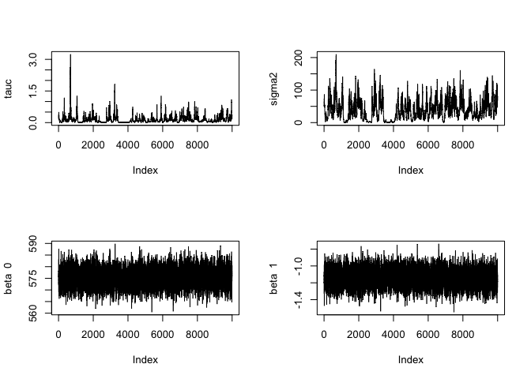

```r
names(sat.analysis)
```

```
##  [1] "H"             "MCMC"          "beta.median"   "beta.hpd"
##  [5] "tauc.median"   "tauc.hpd"      "sigma2.median" "sigma2.hpd"
##  [9] "tauc.accept"   "sigma2.accept" "fit.dist"      "reg.medians"
## [13] "reg.hpd"
```

# 5 Example: Objective Model Selection for Areal Data

```r
# read in the data as contained in the spdep package
columbus <- st_read(system.file("shapes/columbus.gpkg", package = "spData")[1],
    quiet = TRUE)
```

Similarly to the last example, we can plot the response variable, residential crime rate, over the geographic region to visualize which of the 49 neighborhoods have the highest observed crime rates.

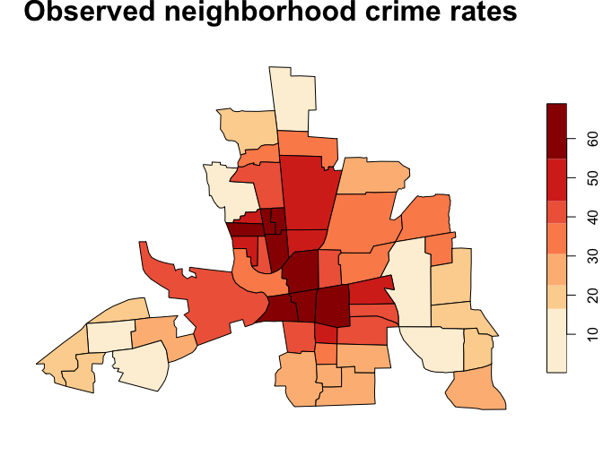

Figure 4: Plot of observed crime rates for Columbus, OH neighborhoods

```r
breaks <- c(0.178, 16.5, 22.5, 30.5, 38.3, 44, 54.8, 68.9)

plot(columbus["CRIME"], breaks = breaks, pal = brewer.pal(7,
    "OrRd"), main = "Observed neighborhood crime rates", cex.main = 2)
```

Upon reading in the data, we can begin to fit each of the candidate models for the data based on combinations of the covariates and whether or not the model contains ICAR random effects. We consider all possible OLMs and ICAR models from the 5 candidate covariates, resulting in a model space of size $2 \times 2^5=64$. Each of the candidate ICAR models uses the same neighborhood matrix $H$, based on the 49 subregions, which we can define as follows.

```r
# create neighborhood matrix
columbus.listw <- poly2nb(columbus)
summary(columbus.listw)
```

```
## Neighbour list object:
## Number of regions: 49
## Number of nonzero links: 236
## Percentage nonzero weights: 9.829238
## Average number of links: 4.816327
## Link number distribution:
##
##  2  3  4  5  6  7  8  9 10
##  5  9 12  5  9  3  4  1  1
## 5 least connected regions:
## 1 6 42 46 47 with 2 links
## 1 most connected region:
## 20 with 10 links
```

```r
W <- nb2mat(columbus.listw, style = "B")
Dmat <- diag(apply(W, 1, sum))
num.reg <- length(columbus$CRIME)

H <- Dmat - W
H <- (H + t(H))/2
rownames(H) <- NULL
isSymmetric(H)  # check that neighborhood matrix is symmetrix before proceeding
```

```
## [1] TRUE
```

```r
# spectral quantities for use in model selection
H.spectral <- eigen(H, symmetric = TRUE)
Q <- H.spectral$vectors
eigH <- H.spectral$values
phimat <- diag(1/sqrt(eigH[1:(num.reg - 1)]))
Sig_phi <- matrix(0, num.reg, num.reg)  #initialize
for (i in 1:(num.reg - 1)) {
    total <- (1/(eigH[i])) * Q[, i] %*% t(Q[, i])
    Sig_phi <- Sig_phi + total
}

# define response and design matrix
Y <- columbus$CRIME
X <- cbind(1, columbus$HOVAL, columbus$INC, columbus$OPEN,
    columbus$PLUMB, columbus$DISCBD)
b <- (ncol(X) + 1)/num.reg  # specify the minimal training size for this example

# perform model selection
columbus.select <- probs.icar(Y = Y, X = X, H = H, H.spectral = H.spectral,
    Sig_phi = Sig_phi, b = b, verbose = FALSE)

# print the model with highest posterior model
# probability
columbus.select$probs.mat[which.max(columbus.select$probs.mat[,
    1]), ]
```

```
##    model prob  model type                   model form
## 19  0.1193955 Independent Y ~ Intercept + X1 + X2 + X5
```

```r
# print vector of posterior inclusion probabilities for
# each covariate
post.include.cov <- matrix(NA, nrow = 1, ncol = ncol(X) - 1)
labels <- c(rep(NA, ncol(X) - 1))
for (i in 1:(ncol(X) - 1)) {
    labels[i] <- paste("X", i, sep = "")
}
colnames(post.include.cov) <- labels

for (j in 1:ncol(X) - 1) {
    post.include.cov[, j] <- sum(columbus.select$probs.mat[grep(paste("X",
        j, sep = ""), columbus.select$probs.mat$"model form"),
        1])
}

post.include.cov
```

```
##             X1        X2        X3        X4        X5
## [1,] 0.7454222 0.9238743 0.3009956 0.4312049 0.9273156
```

As an extension to the objective Bayesian model selection for spatial ICAR models, the R package **GLMMselect** uses fractional Bayes factor methodology to simultaneously select fixed effects and random effects in Generalized Linear Mixed Models (GLMMs) where the covariance structure for the random effects is a product of a unknown scalar and a known semi-positive definite matrix. **GLMMselect** (https://CRAN.R-project.org/package=GLMMselect) can currently be used for model selection for Poisson and Bernoulli data, based on the methodology in Xu et al. (2023).

# References

Banerjee, S., Carlin, B. P., and Gelfand, A. E. (2014), *Hierarchical modeling and analysis for spatial data, second edition*, Chapman; Hall/CRC. https://doi.org/10.1201/b17115.

Ferreira, M. A. R., Porter, E. M., and Franck, C. T. (2021), “Fast and scalable computations for Gaussian hierarchical models with intrinsic conditional autoregressive spatial random effects,” *Computational Statistics and Data Analysis*, 162, 107264. https://doi.org/10.1016/j.csda.2021.107264.

Keefe, M. J., Ferreira, M. A. R., and Franck, C. T. (2018), “On the formal specification of sum-zero constrained intrinsic conditional autoregressive models,” *Spatial Statistics*, Elsevier {BV}, 24, 54–65. https://doi.org/10.1016/j.spasta.2018.03.007.

Keefe, M. J., Ferreira, M. A. R., and Franck, C. T. (2019), “Objective Bayesian analysis for Gaussian hierarchical models with intrinsic conditional autoregressive priors,” *Bayesian Analysis*, International Society for Bayesian Analysis, 14, 181–209. https://doi.org/10.1214/18-BA1107.

Xu, S., Ferreira, M. A. R., Porter, E. M., and Franck, C. T. (2023), “Bayesian model selection for generalized linear mixed models,” *Biometrics*, 79, 3266–3278. https://doi.org/10.1111/biom.13896.